# Project1_Analysis

Kshitij Bhat

11 October 2018

```r
library(nycflights13)
library("ggplot2")

# lets take out the sample where ther is no NA values in delay and has delay greater than 20 minutes

no_na_data_frame <- flights[!is.na(flights$dep_delay) & flights$dep_delay > 20,]


# lets see which flight has maximum departure data

max_delay_main <- max(flights$dep_delay,na.rm = TRUE)

cat("The maximum delay in flights in 2013 is ",max_delay_main," minutes" )
```

```
## The maximum delay in flights in 2013 is  1301  minutes
```

#### Below is the outlier function used from existing sources to compare the data performance with and without outliers.

```r
outlierKD <- function(dt, var) {
     var_name <- eval(substitute(var),eval(dt))
     na1 <- sum(is.na(var_name))
     m1 <- mean(var_name, na.rm = T)
     par(mfrow=c(2, 2), oma=c(0,0,3,0))
     boxplot(var_name, main="With outliers")
     hist(var_name, main="With outliers", xlab=NA, ylab=NA)
     outlier <- boxplot.stats(var_name)$out
     mo <- mean(outlier)
     var_name <- ifelse(var_name %in% outlier, NA, var_name)
     boxplot(var_name, main="Without outliers")
     hist(var_name, main="Without outliers", xlab=NA, ylab=NA)
     title("Outlier Check", outer=TRUE)
     na2 <- sum(is.na(var_name))
     cat("Outliers identified:", na2 - na1, "n")
     cat("Propotion (%) of outliers:", round((na2 - na1) / sum(!is.na(var_name))*100, 1), "n")
     cat("Mean of the outliers:", round(mo, 2), "n")
     m2 <- mean(var_name, na.rm = T)
     cat("Mean without removing outliers:", round(m1, 2), "n")
     cat("Mean if we remove outliers:", round(m2, 2), "n")
     response <- "y"
       #readline(prompt="Do you want to remove outliers and to replace with NA? [yes/no]: ")
     if(response == "y" | response == "yes"){
          dt[as.character(substitute(var))] <- invisible(var_name)
          assign(as.character(as.list(match.call())$dt), dt, envir = .GlobalEnv)
          cat("Outliers successfully removed", "n")
          return(invisible(dt))
     } else{
          cat("Nothing changed", "n")
          return(invisible(var_name))
     }
}
```

#### A histogram of the delays by the airline carriers

```r
head(flights)
```

```
## # A tibble: 6 x 19
##    year month   day dep_time sched_dep_time dep_delay arr_time
##   <int> <int> <int>    <int>          <int>     <dbl>    <int>
## 1  2013     1     1      517            515         2      830
## 2  2013     1     1      533            529         4      850
## 3  2013     1     1      542            540         2      923
## 4  2013     1     1      544            545        -1     1004
## 5  2013     1     1      554            600        -6      812
## 6  2013     1     1      554            558        -4      740
## # ... with 12 more variables: sched_arr_time <int>, arr_delay <dbl>,
## #   carrier <chr>, flight <int>, tailnum <chr>, origin <chr>, dest <chr>,
## #   air_time <dbl>, distance <dbl>, hour <dbl>, minute <dbl>,
## #   time_hour <dttm>
```

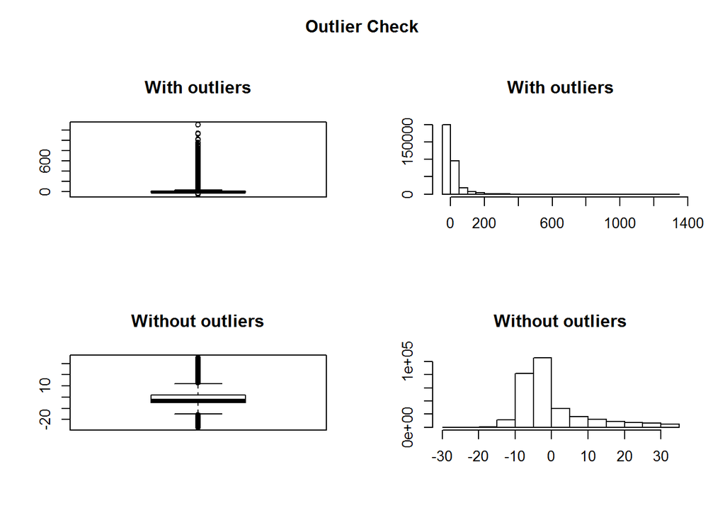

```
## Outliers identified: 43216 nPropotion (%) of outliers: 15.1 nMean of the outliers: 93.15 nMean without removing outliers: 12.64 nMean if we remove outliers: 0.44 nOutliers successfully removed n
```

```r
outlierKD(flights,dep_delay)
```

```r
hist(flights$dep_delay,xlab = "Delay in minutes",main = " Departure delays")

cat("Lets see how the delays vary for different carriers")
```

[output not shown]

```
## Lets see how the delays vary for different carriers
```

```
## Lets check if carrier and distance contribute in predicting the departure_delay
```

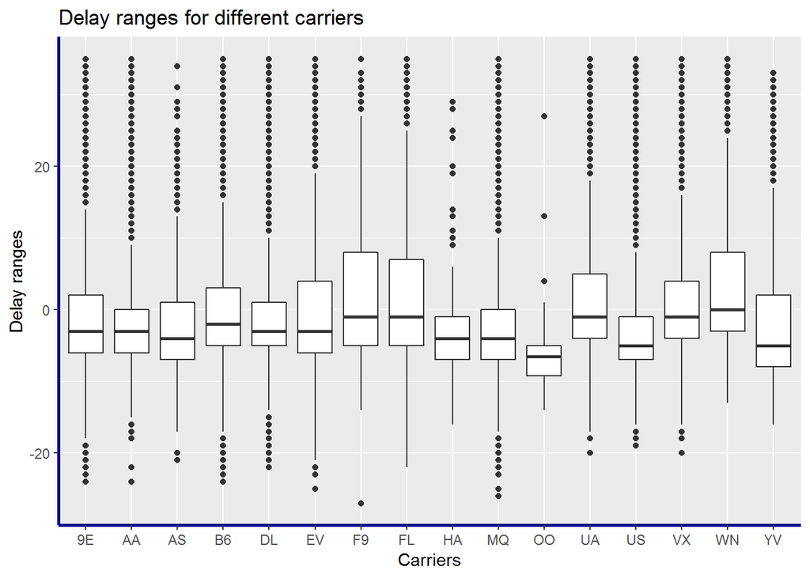

```r
#boxplot(flights$dep_delay[flights$dep_delay>0] ~ flights$carrier[flights$dep_delay>0], main="Departure delays for different carriers",xlab="Carrier",ylab="Delay in minutes")
ggplot(data = flights[!is.na(flights$dep_delay),],aes(x=carrier,y=dep_delay)) +
  geom_boxplot()+
  xlab("Carriers") +
  ylab("Delay ranges") +
  ggtitle("Delay ranges for different carriers") +
  theme( axis.line = element_line(colour = "darkblue", size = 1, linetype = "solid"))
cat("Lets check if carrier and distance contribute in predicting the departure_delay\n")
```

#### A barplot to see how many delays more than 20 minutes occurred each month

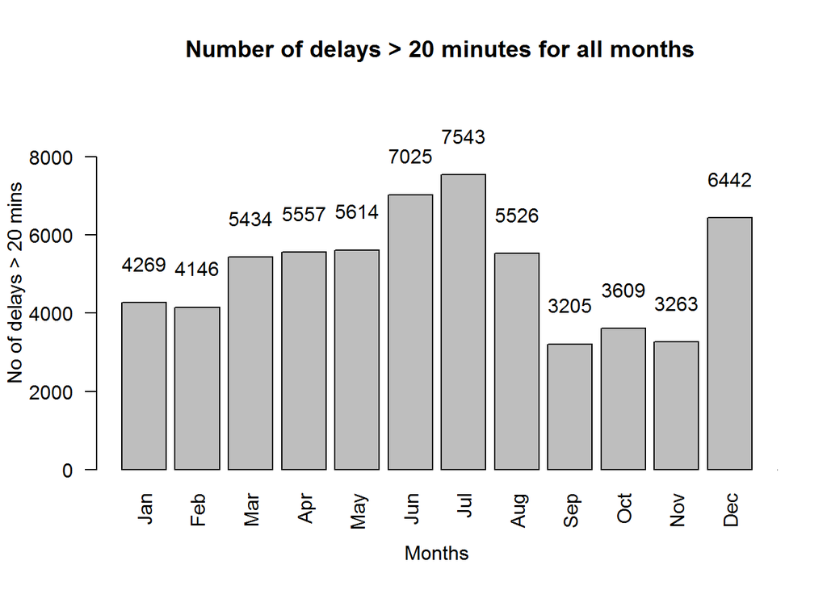

```r
delay_per_month <- c()
total_flights <- c()
for (i in 1:12)
{
  delay_count <- length(no_na_data_frame$month[no_na_data_frame$month == i])
  total_flights <- append(total_flights,length(flights$month[flights$month == i]))
  delay_per_month <- append(delay_per_month,delay_count)
}


plt <- barplot(delay_per_month,
               names.arg = month.abb,
               ylim = c(0,max(delay_per_month)+2000),
               main=" Number of delays > 20 minutes for all months",
               xlab = "Months",
               ylab = "No of delays > 20 mins",
               las =2
                 )
y <- as.matrix(delay_per_month)

text(plt,y+1000,labels =as.character(delay_per_month))

axis(1,at=delay_per_month,labels = month.abb)
```

#### We can infer from the above barplot that the months of June, July, and December have most number of delays greater than 20 minutes

#### Plot to see percentage of flights are being delayed in different months of a year

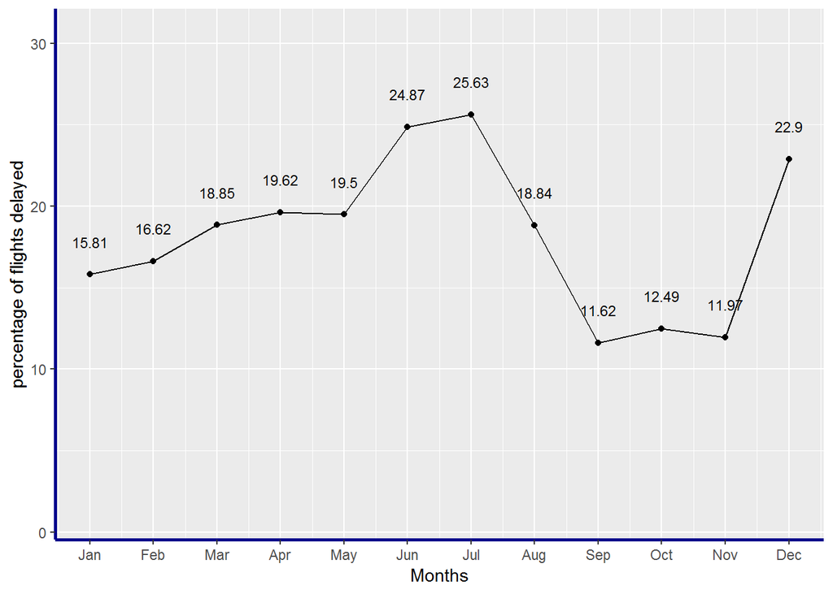

```r
library(ggplot2)

# List to contain the percentage of total flights delayed each month
delay_perc = round((delay_per_month*100)/total_flights,2)

 ggplot(mapping = aes(1:12,delay_perc)) +
   geom_line() + geom_point() +
   scale_x_continuous(breaks=1:12,labels = month.abb) +
   xlab("Months") + ylab("percentage of flights delayed") +
   scale_y_continuous(limits = c(1,max(delay_perc)+5)) +
   theme( axis.line = element_line(colour = "darkblue", size = 1, linetype = "solid")) +
   geom_text(aes(label = delay_perc,y=delay_perc + 2), size = 3)
```

#### Comparing the total flights and delayed flights (> 20 mins) per month

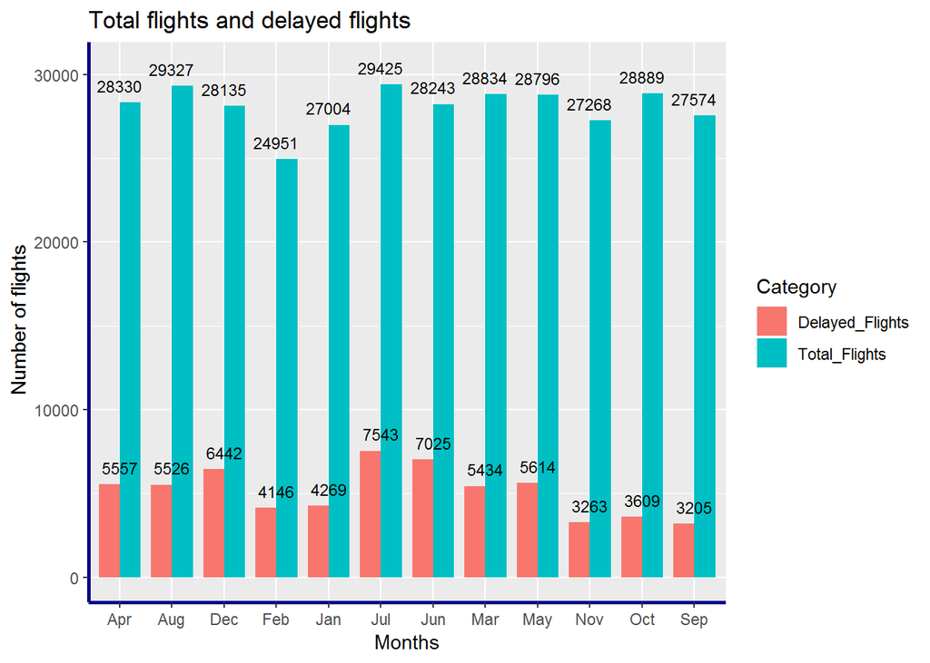

```r
groups <- rep(c("Delayed_Flights","Total_Flights"), 12)



#creating a list of pair of delay flight and total flights
yvals <- c()

for (i in 1:12){
  yvals <- append(yvals,delay_per_month[i])
  yvals <- append(yvals,total_flights[i])


}

comp_df <- data.frame("Months"=rep(month.abb,each=2),"Category"= groups, "Total_Flights" = yvals )

ggplot(data = comp_df,aes(fill= Category, y=Total_Flights,x=Months)) +
    geom_bar(position="dodge",stat="identity",width =0.8) +
    theme( axis.line = element_line(colour = "darkblue", size = 1, linetype = "solid")) +
   geom_text(aes(label = comp_df$Total_Flights,y=comp_df$Total_Flights + 1000), size = 3)+
  ggtitle("Total flights and delayed flights") +
  ylab(" Number of flights")
```

#### lets get a plot where we would know number of delays versus total delays more than 20 minutes by different airlines for the year 2013.

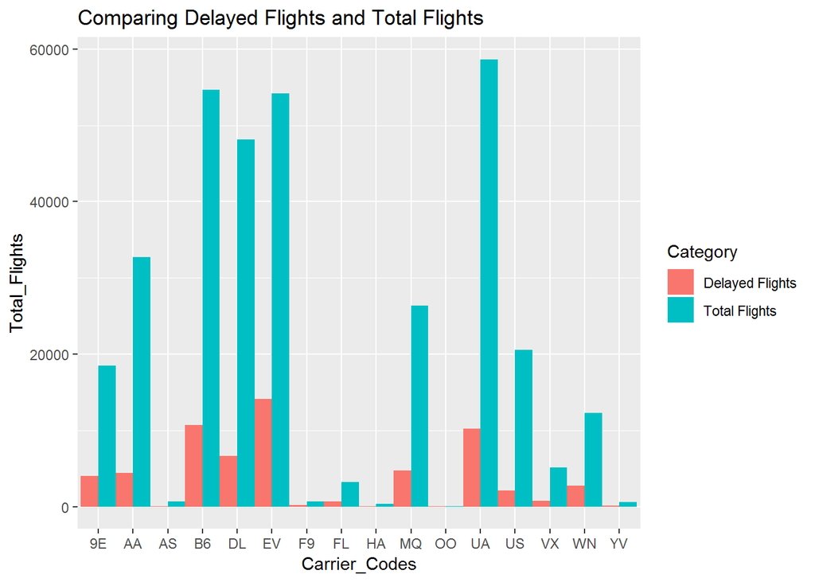

```r
library(ggplot2)
# lets take out the list of unique aircraft carriers which have a positive delay

car_list <- unique(no_na_data_frame$carrier)

# create a dataframe which has the count of delays by a carrier

delay_frame <- data.frame("Carrier_Code"=c(),"Carrier_Name"=c(),"Delay_Count"=c(),"Total_Flights"=c())



for (i in 1:length(car_list)){
   delay_frame[i,"Carrier_Code"] <- car_list[i]
   delay_frame[i,"Carrier_Name"] <- airlines$name[airlines$carrier == car_list[i]]
  delay_frame[i,"Delay_Count"] <- length(no_na_data_frame$dep_delay[no_na_data_frame$carrier == car_list[i]])
  delay_frame[i,"Total_Flights"] <- length(flights$flight[flights$carrier == car_list[i]])

}

xvals <- c()
yvals<- c()

for (k in 1:nrow(delay_frame)) {
  xvals <- append(xvals,rep(delay_frame$Carrier_Code[k],2))
}

for (j in 1:length(xvals))
{
  if(j%%2 ==0)
  {
    yvals <- append(yvals,delay_frame$Total_Flights[delay_frame$Carrier_Code == xvals[j]])
  }
  else
  {
    yvals <- append(yvals,delay_frame$Delay_Count[delay_frame$Carrier_Code == xvals[j]])
  }
}


groups <- rep(c("Delayed Flights","Total Flights"),nrow(delay_frame))

plot_df <- data.frame("Carrier_Codes"= xvals,"Category"=groups,"Total_Flights"=yvals)


ggplot(data=plot_df, aes(fill=Category,y=Total_Flights,x=Carrier_Codes)) +
    geom_bar(position="dodge",stat="identity",width =1) +
  ggtitle("Comparing Delayed Flights and Total Flights")
```

#### During the year 2013, for the flights that departed New York City, we can see that:

#### Approximately 1/4th of the number of flights by ExpressJet Airlines have a delay greater than 20 minutes

#### Approximately 1/5th of the number of flights by Jet Blue Airways have a delay greater than 20 minutes

#### Approximately 1/6th of the number of flights by United Airlines have a delay greater than 20 minutes

#### Note: In the above obseravations, the flight delays are not considered in delay counts when the field value for departure delay is ‘NA’.

```r
# first lets have a look at planes dataframe

head(planes)
```

```
## # A tibble: 6 x 9
##   tailnum  year type       manufacturer  model  engines seats speed engine
##   <chr>   <int> <chr>      <chr>         <chr>    <int> <int> <int> <chr>
## 1 N10156   2004 Fixed win~ EMBRAER       EMB-1~       2    55    NA Turbo~
## 2 N102UW   1998 Fixed win~ AIRBUS INDUS~ A320-~       2   182    NA Turbo~
## 3 N103US   1999 Fixed win~ AIRBUS INDUS~ A320-~       2   182    NA Turbo~
## 4 N104UW   1999 Fixed win~ AIRBUS INDUS~ A320-~       2   182    NA Turbo~
## 5 N10575   2002 Fixed win~ EMBRAER       EMB-1~       2    55    NA Turbo~
## 6 N105UW   1999 Fixed win~ AIRBUS INDUS~ A320-~       2   182    NA Turbo~
```

```r
# lets chose the relevant columns: tailnum,manufacturer, speed

plane_df <- subset(planes,select = c("tailnum","manufacturer","speed"))

# lets merge the flights dataframe (with delay > 20 minutes) with planes dataframe

flight_plane_df <- merge.data.frame(no_na_data_frame,plane_df,by ="tailnum")

head(flight_plane_df)
```

```
##   tailnum year month day dep_time sched_dep_time dep_delay arr_time
## 1  N10156 2013     1  22     2254           2159        55     2352
## 2  N10156 2013     1  10     1120           1032        48     1320
## 3  N10156 2013    10   6     2218           2129        49     2321
## 4  N10156 2013     4  11     2215           2059        76       17
## 5  N10156 2013     5  19     1918           1703       135     2123
## 6  N10156 2013     1  10     1619           1540        39     1831
##   sched_arr_time arr_delay carrier flight origin dest air_time distance
## 1           2300        52      EV   4519    EWR  BWI       40      169
## 2           1240        40      EV   4269    EWR  CHS       99      628
## 3           2239        42      EV   4186    EWR  DCA       39      199
## 4           2256        81      EV   4368    EWR  DAY       88      533
## 5           1859       144      EV   4532    EWR  CHS       89      628
## 6           1744        47      EV   4667    EWR  MSP      175     1008
##   hour minute           time_hour manufacturer speed
## 1   21     59 2013-01-22 21:00:00      EMBRAER    NA
## 2   10     32 2013-01-10 10:00:00      EMBRAER    NA
## 3   21     29 2013-10-06 21:00:00      EMBRAER    NA
## 4   20     59 2013-04-11 20:00:00      EMBRAER    NA
## 5   17      3 2013-05-19 17:00:00      EMBRAER    NA
## 6   15     40 2013-01-10 15:00:00      EMBRAER    NA
```

#### Lets see if delays are common between a particular set of origin and destination airports

```r
#
airport_df <- subset(airports, select = c("faa","name"))


# pick only relevant fields from no_na_data_frame
flight_sub_df <- subset(no_na_data_frame,select = c("carrier","origin","dest","dep_delay","arr_delay"))
flight_airport <- merge.data.frame(flight_sub_df,airport_df,by.x = "dest", by.y = "faa")
head(flight_airport)
```

```
##   dest carrier origin dep_delay arr_delay
## 1  ABQ      B6    JFK        31        32
## 2  ABQ      B6    JFK        24        29
## 3  ABQ      B6    JFK        30        40
## 4  ABQ      B6    JFK        21        31
## 5  ABQ      B6    JFK        22        18
## 6  ABQ      B6    JFK       142       149
##                                name
## 1 Albuquerque International Sunport
## 2 Albuquerque International Sunport
## 3 Albuquerque International Sunport
## 4 Albuquerque International Sunport
## 5 Albuquerque International Sunport
## 6 Albuquerque International Sunport
```

#### We would want to see if there is a correlation between flight arrival delays and other features of the flight dataset

#### Below are the some of the linear models created and their summary

```r
lm1<-lm(arr_delay ~ flight+ distance + air_time,data = no_na_data_frame)
summary(lm1)
```

```
##
## Call:
## lm(formula = arr_delay ~ flight + distance + air_time, data = no_na_data_frame)
##
## Residuals:
##     Min      1Q  Median      3Q     Max
## -110.89  -42.88  -18.92   22.83 1224.73
##
## Coefficients:
##               Estimate Std. Error t value Pr(>|t|)
## (Intercept) 60.3612745  0.8327489  72.484   <2e-16 ***
## flight       0.0002580  0.0001745   1.479    0.139
## distance    -0.0938818  0.0025890 -36.261   <2e-16 ***
## air_time     0.7104859  0.0203055  34.990   <2e-16 ***
## ---
## Signif. codes:  0 '***' 0.001 '**' 0.01 '*' 0.05 '.' 0.1 ' ' 1
##
## Residual standard error: 65.07 on 61181 degrees of freedom
##   (448 observations deleted due to missingness)
## Multiple R-squared:  0.02275,    Adjusted R-squared:  0.02271
## F-statistic: 474.8 on 3 and 61181 DF,  p-value: < 2.2e-16
```

```r
aov(lm1)
```

```
## Call:
##    aov(formula = lm1)
##
## Terms:
##                    flight  distance  air_time Residuals
## Sum of Squares     374497    473254   5184002 259059576
## Deg. of Freedom         1         1         1     61181
##
## Residual standard error: 65.07161
## Estimated effects may be unbalanced
## 448 observations deleted due to missingness
```

```r
lm2<-lm(arr_delay ~ dep_delay + flight+ distance + air_time,data = no_na_data_frame)
summary(lm2)
```

```
##
## Call:
## lm(formula = arr_delay ~ dep_delay + flight + distance + air_time,
##     data = no_na_data_frame)
##
## Residuals:
##      Min       1Q   Median       3Q      Max
## -108.720  -11.659   -3.027    7.644  149.062
##
## Coefficients:
##               Estimate Std. Error  t value Pr(>|t|)
## (Intercept) -1.516e+01  2.621e-01  -57.841  < 2e-16 ***
## dep_delay    1.002e+00  1.246e-03  804.658  < 2e-16 ***
## flight      -3.670e-04  5.128e-05   -7.156 8.37e-13 ***
## distance    -1.016e-01  7.608e-04 -133.591  < 2e-16 ***
## air_time     7.878e-01  5.967e-03  132.017  < 2e-16 ***
## ---
## Signif. codes:  0 '***' 0.001 '**' 0.01 '*' 0.05 '.' 0.1 ' ' 1
##
## Residual standard error: 19.12 on 61180 degrees of freedom
##   (448 observations deleted due to missingness)
## Multiple R-squared:  0.9156, Adjusted R-squared:  0.9156
## F-statistic: 1.66e+05 on 4 and 61180 DF,  p-value: < 2.2e-16
```

```r
aov(lm2)
```

```
## Call:
##    aov(formula = lm2)
##
## Terms:
##                 dep_delay    flight  distance  air_time Residuals
## Sum of Squares  236166169     34699    153943   6371248  22365269
## Deg. of Freedom         1         1         1         1     61180
##
## Residual standard error: 19.11976
## Estimated effects may be unbalanced
## 448 observations deleted due to missingness
```

```r
#t-tests
carrier_arrivaldel<-t.test(flight_airport$arr_delay)
carrier_arrivaldel
```

```
##
##  One Sample t-test
##
## data:  flight_airport$arr_delay
## t = 259.29, df = 59956, p-value < 2.2e-16
## alternative hypothesis: true mean is not equal to 0
## 95 percent confidence interval:
##  69.45688 70.51493
## sample estimates:
## mean of x
##  69.98591
```

```r
carrier_depdel<-t.test(flight_airport$dep_delay)
carrier_depdel
```

```
##
##  One Sample t-test
##
## data:  flight_airport$dep_delay
## t = 289.92, df = 60398, p-value < 2.2e-16
## alternative hypothesis: true mean is not equal to 0
## 95 percent confidence interval:
##  73.21418 74.21084
## sample estimates:
## mean of x
##  73.71251
```

```r
arrivaldep<-t.test(flight_airport$dep_delay, flight_airport$arr_delay, paird=TRUE)
arrivaldep
```

```
##
##  Welch Two Sample t-test
##
## data:  flight_airport$dep_delay and flight_airport$arr_delay
## t = 10.05, df = 119870, p-value < 2.2e-16
## alternative hypothesis: true difference in means is not equal to 0
## 95 percent confidence interval:
##  2.999840 4.453371
## sample estimates:
## mean of x mean of y
##  73.71251  69.98591
```

#### The purpose of this code is to plot bar graphs showing the percentage of flights that each carrier suffers delays from

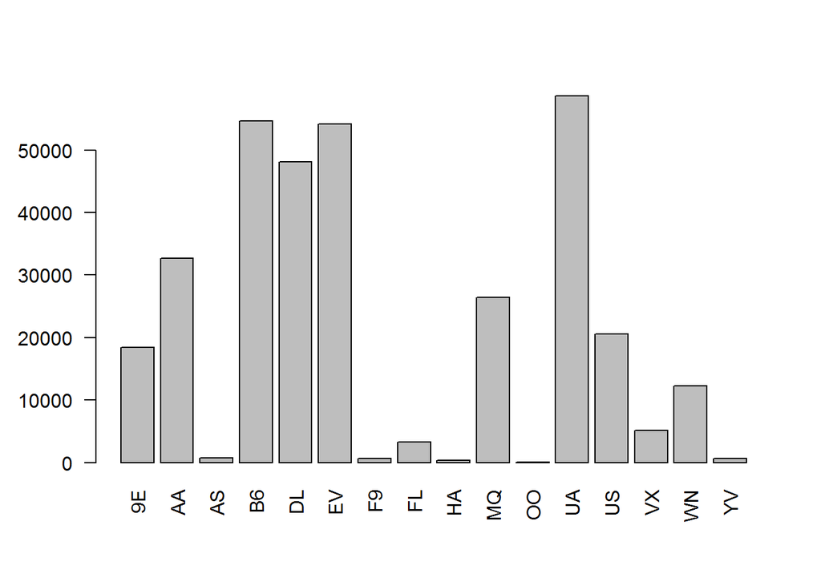

```r
tableTotal <- table(c(flights$carrier)) #this just shows all of the flights, delayed or not
barplot(tableTotal, las=2)
```

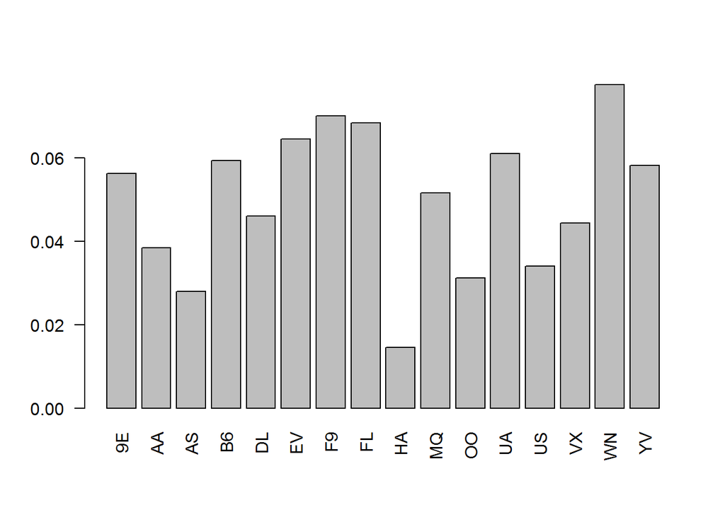

```r
#prep work here is the same for all 3
lateDeparture<-subset(flights, flights$dep_delay > 20) #subset the flights data set into the specific delays we want
v3<-c(lateDeparture$carrier) #combine into a vector
tablev3<-table(v3) #put the vector in a table for the barplot later.

lateArrival<-subset(flights, flights$arr_delay > 20)
v4<-c(lateArrival$carrier)
tablev4<-table(v4)

lateBoth<-subset(lateDeparture, lateDeparture$arr_delay > 20)
v5<-c(lateBoth$carrier)
tablev5<-table(v5)


#this portion of the code iterates through, calculates, and updates the tables with the percentages of delays per total flights, instaed of just total flights
v3SumTotal = 0
v4SumTotal = 0
v5SumTotal = 0
for (i in 1:length(tableTotal)) {
  v3SumTotal = v3SumTotal + (tablev3[i] / tableTotal[i])
  tablev3[i] = tablev3[i] / tableTotal[i]
}
barplot(tablev3, las=2) #and then plot it.
```

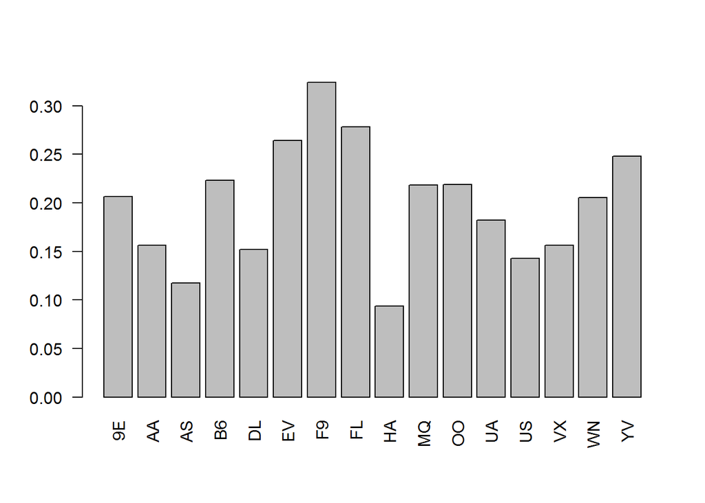

```r
for (i in 1:length(tableTotal)) {
  v4SumTotal = v4SumTotal + (tablev4[i] / tableTotal[i])
  tablev4[i] = tablev4[i] / tableTotal[i]
}
barplot(tablev4, las=2)
```

```r
for (i in 1:length(tableTotal)) {
  v5SumTotal = v5SumTotal + (tablev5[i] / tableTotal[i])
  tablev5[i] = tablev5[i] / tableTotal[i]
}

print(v3SumTotal/length(tableTotal))
```

```
##         9E
## 0.05027088
```

```r
print(v4SumTotal/length(tableTotal))
```

```
##       9E
## 0.199213
```

```r
print(v5SumTotal/length(tableTotal))
```

```
##         9E
## 0.02534095
```

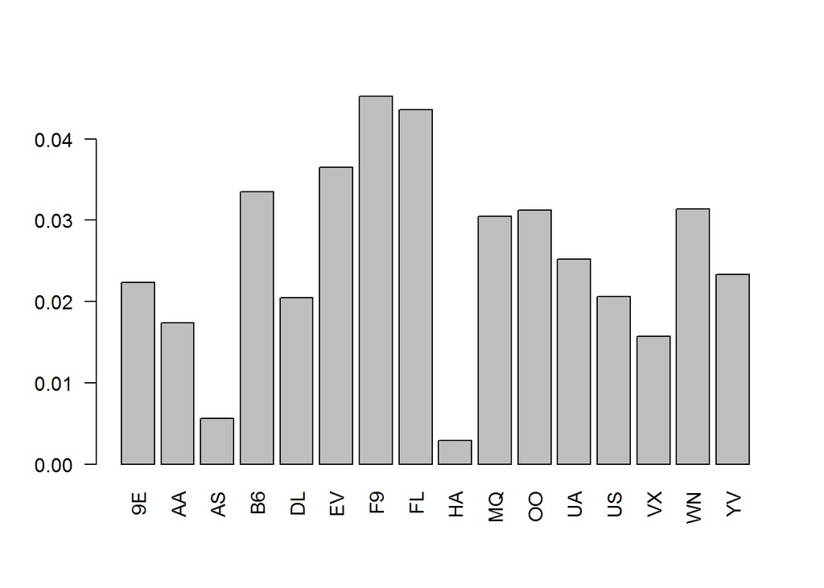

```r
barplot(tablev5, las=2)
```

```r
#chisq.test(tablev3, tablev5)
```

#### This code generates a 3D histogram showing side-by-side the frequency of various delays for each of the carriers.

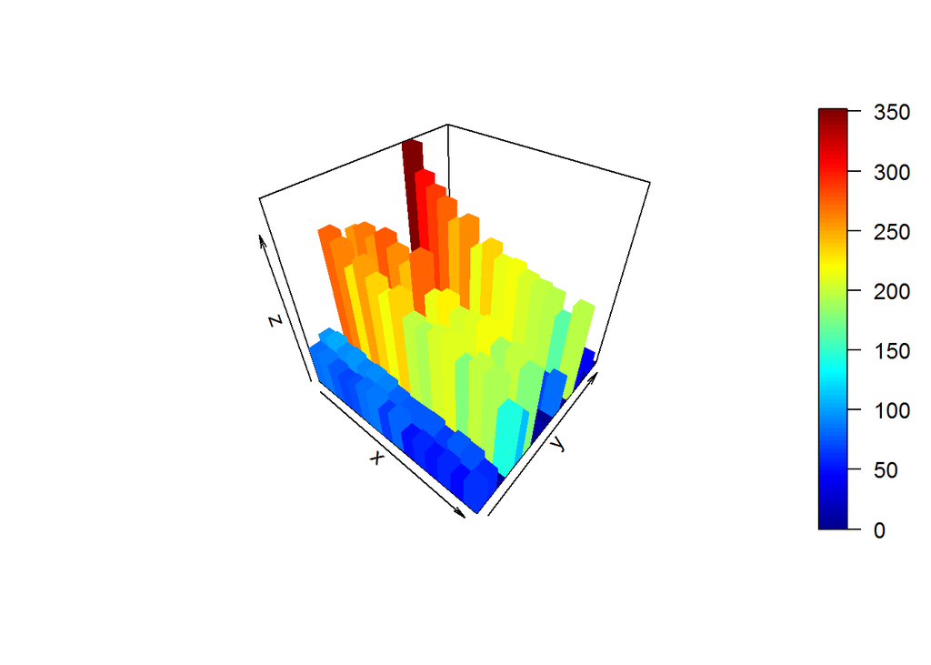

```r
y_3d <- lateDeparture$carrier #y axis denotes the carriers
x_3d <- lateDeparture$dep_delay #x axis denotes the departure delay
z_3d <- table(x_3d, y_3d) #combine
histOutput <- hist3D(z=z_3d) #plot onto 3D hist. I spent a long time trying to affix labels with this package, and could not get them to showup, so I applied them manually after some testing to make sure I was labelling correctly.
```

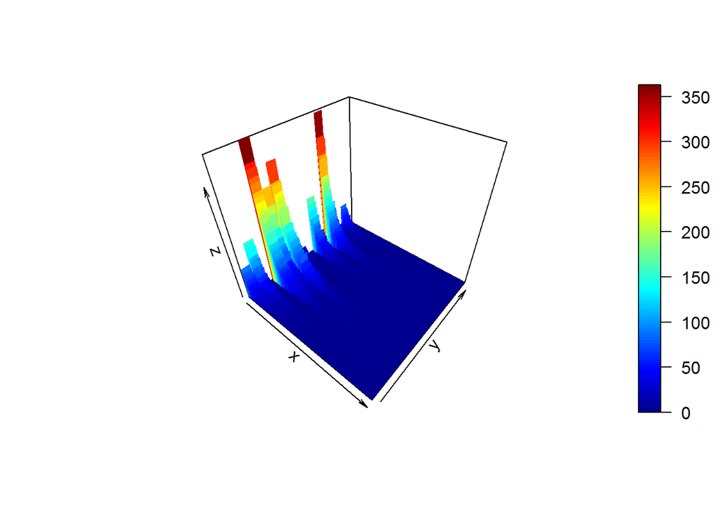

```r
#This is the same 3D histogram for arrival delay.
y_3d2 <- lateArrival$carrier #y axis denotes the carriers
x_3d2 <- lateArrival$arr_delay #x axis denotes the departure delay
z_3d2 <- table(x_3d2, y_3d2) #combine
histOutput <- hist3D(z=z_3d2)
```